# 5160 - hw7

Mostafa

4/13/2021

# 1.a. Transforming / Differencing

```r
library(TSA) # Load the TSA package
library(tseries) # Load the tseries package
```

## TS Plot

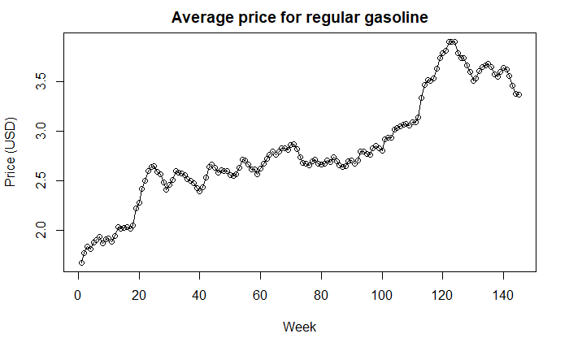

```r
# Load and plot the data
gasprices<- ts(read.table(file = "gasprices.txt"))
plot(gasprices, ylab = "Price (USD)", xlab = "Week", type = "o", main = "Average price for regular gasoline" )
```

## Transformation if nonconstant variance

- No non-constant variance in TS plot ==> No need to transformation.
- CI lambda: .6-1.8 ==> No common transformation in this interval

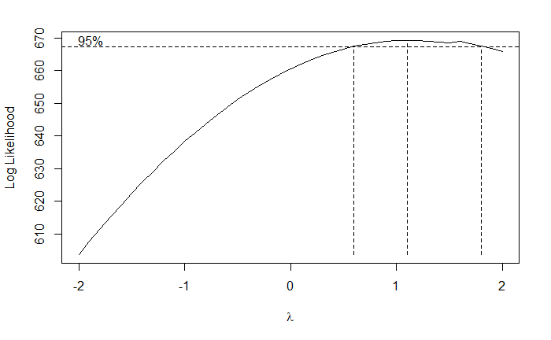

```r
# Profile log-likelihood of lambda (for Box Cox transformation)
# This can be computationally intense (time consuming)
BoxCox.ar(gasprices,method="burg")
```

## adf.test(): H0: non-stationsry

The large p-value here (`0.5492`) does not reject the null hypothesis. There is insufficient evidence to conclude that the `gasprices` process is stationary.

```r
adf.test(gasprices)
```

```
    Augmented Dickey-Fuller Test

data:  gasprices
Dickey-Fuller = -2.0655, Lag order = 5, p-value = 0.5492
alternative hypothesis: stationary
```

## acf(): decay very slowly?

**It seems that differencing is needed.**

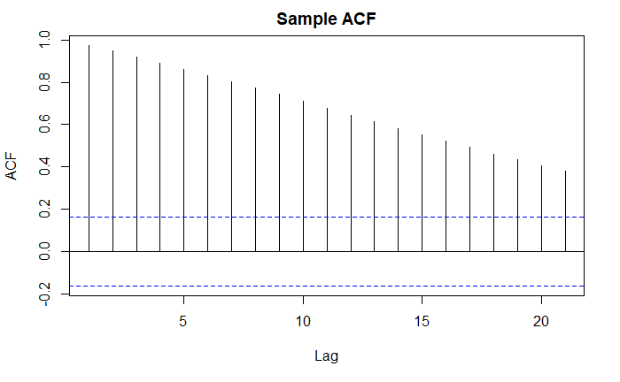

```r
acf(gasprices,main="Sample ACF")
```

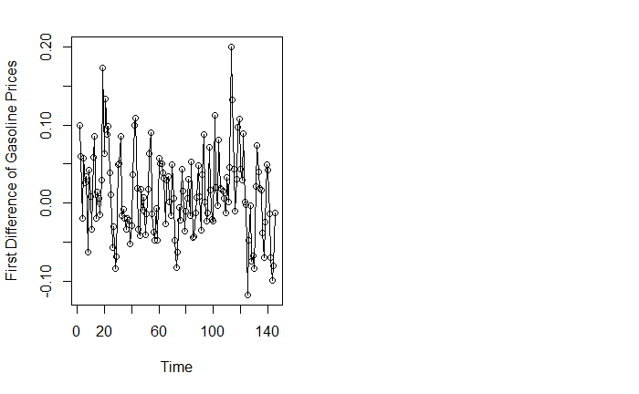

```r
par(mfrow=c(1,2))
plot(diff(gasprices),ylab="First Difference of Gasoline Prices", xlab="Time",type="o")
acf(diff(gasprices),main="Sample ACF")
```

[output not shown]

## adf.test() ==> stationary?

H0: non-stationarity versus H1: stationarity  
`p-value = 0.01` ==> The null hypothesis is rejected. ==> Stationary

```r
adf.test(diff(gasprices))
```

```
p-value smaller than printed p-value
```

```
    Augmented Dickey-Fuller Test

data:  diff(gasprices)
Dickey-Fuller = -4.4215, Lag order = 5, p-value = 0.01
alternative hypothesis: stationary
```

**Note**: What does “p-value smaller than printed p-value” mean?  
It means that this algorithm shows `p-value=0.01` if it is smaller or eual to `0.01`.

## pacf() ==> AR(p=1)

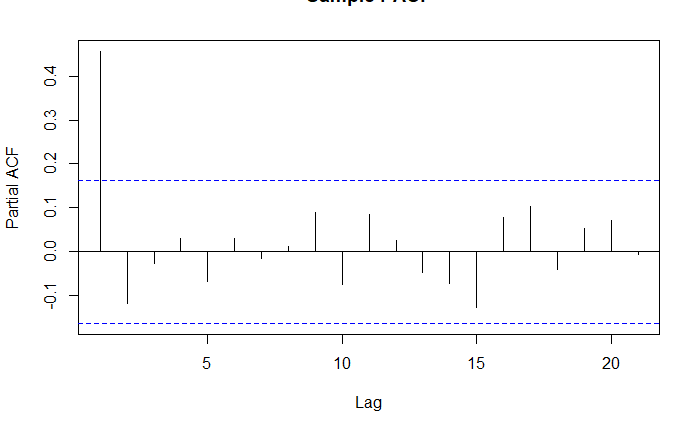

```r
pacf(diff(gasprices),main="Sample PACF")
```

## eacf() ==> ARMA(p,q)

```r
eacf(diff(gasprices))
```

```
AR/MA
  0 1 2 3 4 5 6 7 8 9 10 11 12 13
0 x o o o o o o o o o o  o  o  o
1 x o o o o o o o o o o  o  o  o
2 x x o o o o o o o o o  o  o  o
3 x o o o o o o o o o o  o  o  o
4 x x o o o o o o o o o  o  o  o
5 x o o o o o o o o o o  o  o  o
6 x o o o o o o o o o o  o  o  o
7 x o o x o x o o o o o  o  o  o
```

## ARIMA(p,d,q) ==> ARIMA(1,1,1)

- diff() ==> d=1
- acf(q=1)
- pacf(p=1)
- eacf(p=1,q=1)

**So, this model would be ARIMA(1,1,1)**

# 1.b. Fitting a model

## Fit a model using maximum likelihood

```r
# Fit the model using ARIMA(1,1,1)
arima(gasprices,order=c(1,1,1),method='ML') # maximum likelihood
```

```
Call:
arima(x = gasprices, order = c(1, 1, 1), method = "ML")

Coefficients:
         ar1     ma1
      0.3585  0.1713
s.e.  0.1451  0.1479

sigma^2 estimated as 0.002324:  log likelihood = 232.18,  aic = -460.35
```

## To automatically check the significancy

```r
a = arima(gasprices,order=c(1,1,1),method='ML') # maximum likelihood
# To automatically check the significancy
a$coef/sqrt(diag(a$var.coef))
```

```
     ar1      ma1
2.469858 1.158207
```

## final model

As MA(1) is not significant (between -2 and 2), I go for ARIMA(1,1,0). As we can see, this model is more significant.

```r
arima(gasprices,order=c(1,1,0),method='ML') # maximum likelihood
```

```
Call:
arima(x = gasprices, order = c(1, 1, 0), method = "ML")

Coefficients:
         ar1
      0.4878
s.e.  0.0732

sigma^2 estimated as 0.002344:  log likelihood = 231.57,  aic = -461.14
```

```r
a = arima(gasprices,order=c(1,1,0),method='ML') # maximum likelihood
# To automatically check the significancy
a$coef/sqrt(diag(a$var.coef))
```

```
     ar1
6.658975
```

# 1.c. The diagnostic checks

```r
gasprices.ma1.fit = arima(gasprices,order=c(1,1,0),method='ML') # maximum likelihood
gasprices.ma1.fit
```

```
Call:
arima(x = gasprices, order = c(1, 1, 0), method = "ML")

Coefficients:
         ar1
      0.4878
s.e.  0.0732

sigma^2 estimated as 0.002344:  log likelihood = 231.57,  aic = -461.14
```

## Normality check: qq plot

- Residuals are distributed almost evenly around the the zero line.
- Histogram is almost bell-shaped.
- qqplot: The points are centered and most of the are on the reference line.

**So, we can conclude that it is normaly distributed**.

```r
par(mfrow=c(2,2))
plot(gasprices, ylab = "Price (USD)", xlab = "Week", type = "o", main = "Average price for regular gasoline" )
plot(rstandard(gasprices.ma1.fit),xlab="Time",ylab="Standardised residuals",type='o')
```

```r
abline(h=0)
hist(rstandard(gasprices.ma1.fit),xlab="Standardised residuals",main="")
```

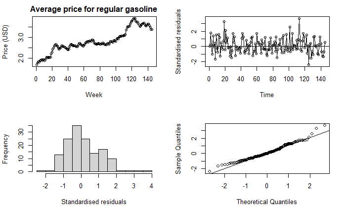

```r
qqnorm(rstandard(gasprices.ma1.fit),main="")
qqline(rstandard(gasprices.ma1.fit))
```

## Normality check: Shapiro-Wilk tests

H0 : the (standardized) residuals are normally distributed.

- As `p-value = 0.006841`, the null hypothesis is rejected. And we can conclude that it is not normally distributed. However I prefer to ignore this result and trust qq plot. Because the tails are less important in a distribution.

```r
# Shapiro-Wilk tests
shapiro.test(rstandard(gasprices.ma1.fit))
```

```
    Shapiro-Wilk normality test

data:  rstandard(gasprices.ma1.fit)
W = 0.9737, p-value = 0.006841
```

## Independency check: RUNS TEST

H0 : the (standardized) residuals are independent  
- A small number of runs would indicate that neighboring values are positively dependent and tend to hang together over time.  
- Too many runs would indicate that the data oscillate back and forth across their median. This suggests that neighboring residuals are negatively dependent.  
- Therefore, either too few or too many runs lead us to reject independence.

**Conclusion**:  
- As the `$observed.runs = 71` is close to `$expected.runs = 73.41379`, we conclude that this amount of runs is not too many or small. So, we can trust the `$pvalue`.  
- As the `$pvalue = 0.749` is large, we can not reject the null hypothesis (residuals are independent). It means that there is not enough evidence to conclude that it is not independent.

```r
# runs test
runs(rstandard(gasprices.ma1.fit))
```

```
$pvalue
[1] 0.749

$observed.runs
[1] 71

$expected.runs
[1] 73.41379

$n1
[1] 75

$n2
[1] 70

$k
[1] 0
```

## To check the quality of fit: acf() of the residuals

To further check the adequacy of a fitted model, we use acf() of the residuals. The lags are supposed to be approximately uncorrelated. It means that none of the sample autocorrelations fall outside the error bounds.

[figure not shown]

```r
acf(rstandard(gasprices.ma1.fit),main="Sample ACF for MA(1) residuals")
```

## To ckeck the Overfitting: ARIMA(p+1,d,q) & ARIMA(p,d,q+1)

IMPORTANT: When overfitting an ARIMA(p, d, q) model, we consider the following two models:  
- (a) ARIMA(p+1,d,q)  
- (b) ARIMA(p,d,q+1)

To ckeck:  
Main model: ARIMA(1,1,0)  
Check 1: ARIMA(2,1,0)  
Check 2: ARIMA(1,1,1)

```r
arima(gasprices,order=c(2,1,0),method='ML') # maximum likelihood
```

```
Call:
arima(x = gasprices, order = c(2, 1, 0), method = "ML")

Coefficients:
         ar1      ar2
      0.5348  -0.0982
s.e.  0.0833   0.0840

sigma^2 estimated as 0.002321:  log likelihood = 232.25,  aic = -460.5
```

```r
arima(gasprices,order=c(1,1,1),method='ML') # maximum likelihood
```

```
Call:
arima(x = gasprices, order = c(1, 1, 1), method = "ML")

Coefficients:
         ar1     ma1
      0.3585  0.1713
s.e.  0.1451  0.1479

sigma^2 estimated as 0.002324:  log likelihood = 232.18,  aic = -460.35
```

**Analysis**:

Always: distribution (approximately 1.96)  
$-0.0982 \ \pm \ 1.96 \ * 0.0840 \ = \ (-0.26284, 0.06644)$: This CI includes zero. Therefore, $\phi_{2}$ is not statistically different than zero, which suggests that the AR(2) model is not necessary.